# Sistemas y Señales Biomédicos

## Step 2: Method 2 - Bilinear Transformation

- **Concept:** An algebraic substitution mapping the $j\Omega$ axis onto the unit circle.
- **Mapping Formula:**
  $$s = \frac{2}{T} \frac{1 - z^{-1}}{1 + z^{-1}}$$
  (T = sampling period, often set to 2 for simplicity during derivation).
- **Pros:**
  - **No aliasing:** Maps entire $j\Omega$ axis to the unit circle ($-\pi \le \omega \le \pi$).
  - **Preserves stability:** Maps LHP (stable s-region) to inside the unit circle (stable z-region).
- **Cons:** Introduces **non-linear frequency warping**.

## Understanding Frequency Warping (Bilinear)

- The relationship between analog ($\Omega$) and digital ($\omega$) frequencies is non-linear:
  $$\Omega = \frac{2}{T} \tan\left(\frac{\omega T}{2}\right)$$
  or equivalently:
  $$\omega = 2 \arctan\left(\frac{\Omega T}{2}\right)$$
- This compresses the infinite analog frequency axis onto the finite digital frequency range $[-\pi, \pi]$.
- The mapping is non-uniform, most distorted near $\omega = \pm \pi$.

## Step 3: Frequency Pre-warping (Bilinear Only)

- **Problem:** Frequency warping distorts the locations of $\omega_p$ and $\omega_s$.
- **Solution:** Pre-warp the *digital* specifications ($\omega_p, \omega_s$) into corresponding *analog* frequencies ($\Omega_p, \Omega_s$) *before* designing the analog filter.
- **Formula:** Use the warping relationship:
  $$\Omega_p = \frac{2}{T} \tan\left(\frac{\omega_p T}{2}\right)$$
  $$\Omega_s = \frac{2}{T} \tan\left(\frac{\omega_s T}{2}\right)$$
- Use these $\Omega_p, \Omega_s$ values for the analog design step.

## Step 4: Analog Prototype Design Workflow

1. **Select Prototype:** Choose Butterworth, Chebyshev, Elliptic based on specs (ripple, transition width) using the (pre-warped) $\Omega_p, \Omega_s, A_p, A_s$.
2. **Determine Order (N) & Cutoff ($\Omega_c$):** Calculate required analog filter order and cutoff frequency using prototype-specific formulas.
3. **Find Normalized LP $H_{LP}(s)$:** Obtain the transfer function for the normalized low-pass prototype.
4. **Frequency Transformation (Analog):** If needed, transform $H_{LP}(s)$ to target type (HP, BP, BS) using analog transformations.
   - **Result:** The final analog filter transfer function $H_a(s)$.

## Analog Filter Design: Overview

Designing an analog filter translates desired signal filtering characteristics into a physical electronic circuit.

**Key Stages:**

1. Define Specifications
2. Choose an Approximation Method
3. Determine Filter Order
4. Find Normalized Low-Pass Prototype (Conceptual)
5. Denormalize & Transform (Conceptual)
6. Synthesize the Circuit
7. Component Selection & Simulation

We’ll illustrate steps 1, 3, and aspects of 4/5 using Python’s `scipy.signal`.

## 1. Define Filter Specifications

This is the most crucial first step.

- **Type:** Low-Pass (LPF), High-Pass (HPF), Band-Pass (BPF), Band-Stop (BSF).
- **Critical Frequencies (Analog, $\Omega$ in rad/s or $f$ in Hz):**
  - Cutoff ($\Omega_c, f_c$)
  - Passband Edge(s) ($\Omega_p, f_p$)
  - Stopband Edge(s) ($\Omega_s, f_s$)
- **Attenuation Levels (dB):**
  - Max. Passband Attenuation/Ripple ($A_{max}$ or `gpass`)
  - Min. Stopband Attenuation ($A_{min}$ or `gstop`)
- **Phase Response:** Linear phase (e.g., Bessel) or not critical.
- **Impedance:** Source/Load matching.

## 1. Specifications: Python Example (Low-Pass)

Let’s define specs for an analog low-pass filter. Frequencies for analog filters in `scipy` are typically in rad/s.

```
Passband edge: 6283.19 rad/s (1000 Hz)
```

```
Stopband edge: 9424.78 rad/s (1500 Hz)
```

```
Max Passband Loss: 1.0 dB
```

```
Min Stopband Attenuation: 40.0 dB
```

## 2. Choose an Approximation Method (Filter Family)

Select based on trade-offs (roll-off, ripple, phase).

- **Butterworth:** Maximally flat passband, smooth roll-off.
- **Chebyshev Type I:** Steeper roll-off than Butterworth, passband ripple.
- **Chebyshev Type II:** Steeper roll-off, stopband ripple, flat passband.
- **Elliptic (Cauer):** Steepest roll-off, ripple in both bands.
- **Bessel-Thomson:** Best phase linearity (constant group delay), slowest roll-off.

*For our Python examples, we’ll use Butterworth.*

## Butterworth Filter Fundamentals

The Butterworth filter is maximally flat in the passband.

The normalized prototype has a cutoff frequency $\omega_c = 1$ rad/s.

Poles are placed on the unit circle in the $s$-plane at angles:
$$s_k = e^{j\pi\frac{2k + n - 1}{2n}}, \quad k = 1,2,\ldots,n.$$

The Butterworth polynomial of order $n$ is:
$$B_n(s) = \prod_{k=1}^{n} (s - s_k).$$

## Normalized Lowpass (LP) Transfer Function

The normalized $n$th-order lowpass prototype is:
$$H_{LP}(s) = \frac{1}{B_n(s)} = \frac{1}{\prod_{k=1}^n (s - s_k)}.$$
This yields a cutoff at $|H_{LP}(j1)| = 1/\sqrt{2}$ (the –3 dB point).

## Normalized Highpass (HP) Transfer Function

Apply the frequency transformation $s \to 1/s$ and multiply by $s^n$:
$$H_{HP}(s) = H_{LP}(1/s)\,s^n = \frac{s^n}{B_n(1/s)} = \frac{s^n}{\prod_{k=1}^n (1/s - s_k)} = \frac{\prod_{k=1}^n(-s_k)\;s^n}{\prod_{k=1}^n(s - s_k^{-1})}.$$
This prototype has a normalized cutoff at $\omega=1$ rad/s in the highpass sense.

## Normalized Bandpass (BP) Transfer Function

Use the bandpass transformation:
$$s \to \frac{s^2 + \Omega_0^2}{B\,s},$$
where $\Omega_0 = \sqrt{\omega_1\omega_2}$ and $B = \omega_2 - \omega_1$.

For a normalized prototype, we set $\Omega_0 = 1$, $B = 1$, giving:
$$H_{BP}(s) = H_{LP}\left(\frac{s^2 + 1}{s}\right) = \frac{(s)^n}{\prod_{k=1}^n\left(\frac{s^2 + 1}{s} - s_k\right)} = \frac{s^n}{\prod_{k=1}^n\left(s^2 + 1 - s\,s_k\right)}.$$

## Normalized Bandstop (BS) Transfer Function

Use the bandstop transformation:
$$s \to \frac{s}{\frac{s^2 + 1}{s}} = \frac{s^2}{s^2 + 1},$$
or equivalently $s \to (B\,s)/(s^2 + \Omega_0^2)$ with $B=1$, $\Omega_0=1$. Then:
$$H_{BS}(s) = H_{LP}\left(\frac{s}{s^2 + 1}\right) = \frac{1}{B_n\left(\frac{s}{s^2+1}\right)} = \frac{1}{\prod_{k=1}^n\left(\frac{s}{s^2+1} - s_k\right)} = \frac{(s^2+1)^n}{\prod_{k=1}^n\left(s - s_k(s^2+1)\right)} = \frac{(s^2+1)^n}{\prod_{k=1}^n\left(s - s_ks^2 - s_k\right)}.$$

## 3. Determine the Filter Order (N)

Estimating the filter order ($N$) is a crucial first step in analog filter design after defining specifications. The order determines the filter’s complexity and steepness of its frequency response roll-off.

These equations are for **Butterworth** filters. The calculated $N$ is a real number and must be rounded up to the next integer.

**Common Variables:** * $N$: Filter order (integer, result of formula is rounded up). * $A_{min}$: Minimum stopband attenuation (dB, positive value, e.g., 40 dB). * $A_{max}$: Maximum passband attenuation/ripple (dB, positive value, e.g., 1 dB). * $\log_{10}$: Base-10 logarithm. * All $\Omega$ values are angular frequencies in rad/s.

## Butterworth Low-Pass (LP) Filter Order

$$N \ge \frac{\log_{10}\left(\frac{10^{A_{min}/10}-1}{10^{A_{max}/10}-1}\right)}{2 \log_{10}\left(\frac{\Omega_s}{\Omega_p}\right)}$$

**Explanation of LP-Specific Variables:** * $\Omega_p$: Passband edge angular frequency. The frequency up to which signals pass with at most $A_{max}$ attenuation. * $\Omega_s$: Stopband edge angular frequency. The frequency from which signals are attenuated by at least $A_{min}$. * For a low-pass filter, $\Omega_s > \Omega_p$. The term $\frac{\Omega_s}{\Omega_p}$ is the transition ratio.

## Butterworth High-Pass (HP) Filter Order

$$N \ge \frac{\log_{10}\left(\frac{10^{A_{min}/10}-1}{10^{A_{max}/10}-1}\right)}{2 \log_{10}\left(\frac{\Omega_p}{\Omega_s}\right)}$$

**Explanation of HP-Specific Variables:** * $\Omega_p$: Passband edge angular frequency. The frequency from which signals pass with at most $A_{max}$ attenuation. * $\Omega_s$: Stopband edge angular frequency. The frequency down to which signals are attenuated by at least $A_{min}$. * For a high-pass filter, $\Omega_p > \Omega_s$. The term $\frac{\Omega_p}{\Omega_s}$ is the transition ratio (inverted compared to LP to keep it >1 for the logarithm).

## Butterworth Band-Pass (BP) Filter Order

The order $N_{BP}$ is the same as an equivalent Low-Pass Prototype.
$$N_{BP} \ge \frac{\log_{10}\left(\frac{10^{A_{min}/10}-1}{10^{A_{max}/10}-1}\right)}{2 \log_{10}\left(\Omega_{s,LP_equiv}\right)}$$

**Explanation of BP-Specific Variables:** * $\Omega_{p1}, \Omega_{p2}$: Passband edge angular frequencies ($\Omega_{p1} < \Omega_{p2}$). * $\Omega_{s1}, \Omega_{s2}$: Stopband edge angular frequencies ($\Omega_{s1} < \Omega_{p1}$ and $\Omega_{s2} > \Omega_{p2}$). * $\Omega_0 = \sqrt{\Omega_{p1}\Omega_{p2}}$: Geometric center frequency of the passband. * $B = \Omega_{p2} - \Omega_{p1}$: Bandwidth of the passband. * $\Omega_{s,LP_equiv} = \min\left( \left| \frac{\Omega_{s1}^2 - \Omega_0^2}{\Omega_{s1} B} \right|, \left| \frac{\Omega_{s2}^2 - \Omega_0^2}{\Omega_{s2} B} \right| \right)$ * This $\Omega_{s,LP_equiv}$ is the stopband edge of an equivalent low-pass prototype whose passband edge is normalized to 1 rad/s. It represents the more stringent of the two possible transitions from the passband edges to the stopband edges.

## Butterworth Band-Stop (BS) Filter Order

The order $N_{BS}$ is the same as an equivalent Low-Pass Prototype.
$$N_{BS} \ge \frac{\log_{10}\left(\frac{10^{A_{min}/10}-1}{10^{A_{max}/10}-1}\right)}{2 \log_{10}\left(\Omega_{trans,LP_equiv}\right)}$$

**Explanation of BS-Specific Variables:** * $\Omega_{s1}, \Omega_{s2}$: Stopband edge angular frequencies defining the rejected band ($\Omega_{s1} < \Omega_{s2}$). $A_{min}$ is the attenuation in this band. * $\Omega_{p1}, \Omega_{p2}$: Passband edge angular frequencies outside the stopband ($\Omega_{p1} < \Omega_{s1}$ and $\Omega_{p2} > \Omega_{s2}$). $A_{max}$ is the ripple in these passbands. * $\Omega_0 = \sqrt{\Omega_{s1}\Omega_{s2}}$: Geometric center frequency of the stopband. * $B = \Omega_{s2} - \Omega_{s1}$: Bandwidth of the stopband. * $\Omega_{p,LP_i} = \left| \frac{\Omega_{pi} B}{\Omega_{pi}^2 - \Omega_0^2} \right|$ for $i=1$ (using $\Omega_{p1}$) and $i=2$ (using $\Omega_{p2}$). * These are the passband edges of an equivalent low-pass prototype whose stopband edge is normalized to 1 rad/s. * $\Omega_{trans,LP_equiv} = \frac{1}{\min(\Omega_{p,LP1}, \Omega_{p,LP2})}$ * This is the effective transition ratio (stopband edge / passband edge) for the equivalent low-pass prototype.

## 3. Determine the Filter Order (N) & Denormalization

Calculated based on specs and chosen filter type. `scipy.signal.buttord` (and similar for other types) can find this for analog filters.

```
Required Butterworth Filter Order (N): 14
```

```
Butterworth Natural Frequency (Wn_buttord): 6593.83 rad/s
```

- `Wn_buttord` is the natural angular frequency ($\Omega_n$) for the filter. For Butterworth, this is the -3dB cutoff frequency $\Omega_c$.

## 3. Determine the Filter Order (N) & Denormalization

### Normalized Lowpass to Denormalized Lowpass

- **Goal:** Transform a normalized LP ($\omega_c = 1$) to a denormalized LP with cutoff $\Omega_c$.
- **Transformation:** Replace $s_{norm}$ with $s / \Omega_c$.
  $$s_{norm} \to \frac{s}{\Omega_c}$$
- **Denormalized Transfer Function:**
  $$H_{LP}(s) = H_{norm}\left(\frac{s}{\Omega_c}\right)$$

## Normalized Lowpass to Denormalized Highpass

- **Goal:** Transform a normalized LP ($\omega_c = 1$) to a denormalized HP with cutoff $\Omega_c$.
- **Transformation:** Replace $s_{norm}$ with $\Omega_c / s$.
  $$s_{norm} \to \frac{\Omega_c}{s}$$
- **Denormalized Transfer Function:**
  $$H_{HP}(s) = H_{norm}\left(\frac{\Omega_c}{s}\right)$$

## Normalized Lowpass to Denormalized Bandpass

- **Goal:** Transform a normalized LP ($\omega_c = 1$) to a denormalized BP with center frequency $\Omega_0$ and bandwidth $B$.
- **Transformation:** Replace $s_{norm}$ with $\frac{s^2 + \Omega_0^2}{B s}$.
  $$s_{norm} \to \frac{s^2 + \Omega_0^2}{B s}$$
- **Parameters:**
  - $\Omega_0 = \sqrt{\Omega_1 \Omega_2}$ (geometric mean)
  - $B = \Omega_2 - \Omega_1$ (bandwidth) ($\Omega_1, \Omega_2$ are the desired band edges in rad/s)
- **Denormalized Transfer Function:**
  $$H_{BP}(s) = H_{norm}\left(\frac{s^2 + \Omega_0^2}{B s}\right)$$

## Normalized Lowpass to Denormalized Bandstop

- **Goal:** Transform a normalized LP ($\omega_c = 1$) to a denormalized BS with center frequency $\Omega_0$ and bandwidth $B$.
- **Transformation:** Replace $s_{norm}$ with $\frac{B s}{s^2 + \Omega_0^2}$.
  $$s_{norm} \to \frac{B s}{s^2 + \Omega_0^2}$$
- **Parameters:**
  - $\Omega_0 = \sqrt{\Omega_1 \Omega_2}$
  - $B = \Omega_2 - \Omega_1$
- **Denormalized Transfer Function:**
  $$H_{BS}(s) = H_{norm}\left(\frac{B s}{s^2 + \Omega_0^2}\right)$$

## 4 & 5. Obtain Analog Filter Transfer Function $H_a(s)$

Conceptually: Find normalized LP prototype $\rightarrow$ Denormalize $\rightarrow$ Transform.

`scipy.signal` functions like `butter`, `cheby1`, etc., (with `analog=True`) perform these steps internally to give the final analog filter transfer function $H_a(s)$.

$H_a(s)$ can be represented as: 1. Numerator ($b$) and Denominator ($a$) coefficients: $H_a(s) = \frac{b_0 s^M + b_1 s^{M-1} + \dots + b_M}{a_0 s^N + a_1 s^{N-1} + \dots + a_N}$ 2. Zeros ($z$), Poles ($p$), and Gain ($k$): $H_a(s) = k \frac{\prod (s-z_i)}{\prod (s-p_j)}$

## 4 & 5. Python: Design $H_a(s)$ (Butterworth LPF)

Using `signal.butter` with `analog=True`. The `Wn` parameter here should be the cutoff frequency $\Omega_c$. For `buttord`, the returned `Wn_buttord` is exactly this $\Omega_c$.

```
Analog Filter Coefficients (Numerator b, Denominator a):
```

```
b_analog = [2.93718174e+53]
```

```
a_analog = [1.00000000e+00 5.88921844e+04 1.73414469e+09 3.37531810e+13
 4.84169654e+17 5.40639098e+21 4.84125527e+25 3.52958830e+29
 2.10491137e+33 1.02201934e+37 3.97946840e+40 1.20619642e+44
 2.69441500e+47 3.97843852e+50 2.93718174e+53]
```

```
Analog Filter Zeros, Poles, Gain (ZPK):
```

```
Zeros (z_analog) = []
```

```
Poles (p_analog) = [ -738.27500968+6552.37193897j -2177.8048373 +6223.80864963j
 -3508.13043664+5583.15760623j -4662.54372722+4662.54372722j
 -5583.15760623+3508.13043664j -6223.80864963+2177.8048373j
 -6552.37193897 +738.27500968j -6552.37193897 -738.27500968j
 -6223.80864963-2177.8048373j  -5583.15760623-3508.13043664j
 -4662.54372722-4662.54372722j -3508.13043664-5583.15760623j
 -2177.8048373 -6223.80864963j  -738.27500968-6552.37193897j]
```

```
Gain (k_analog) = 293718173729774468825490597908032846661500110135885824.00
```

## Visualizing Analog Frequency Response (Python)

Use `scipy.signal.freqs` to compute the frequency response of an analog filter given its $b,a$ coefficients.

```
(100.0, 7500)
```

```
(-60.0, 5.0)
```

```
(100.0, 7500)
```

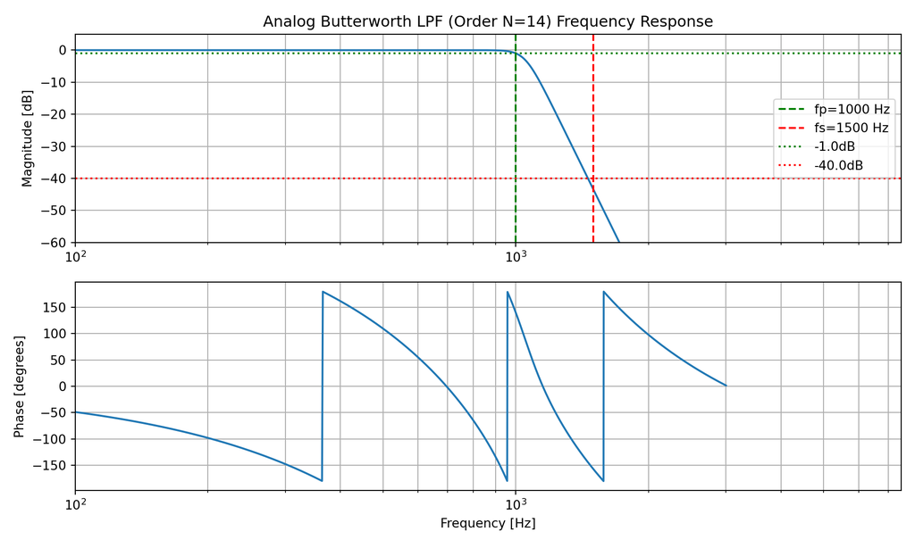

## 6. Synthesize the Circuit (Realization)

Convert the mathematical $H_a(s)$ into a physical electronic circuit. *This step is **not** done by `scipy.signal`. It requires circuit design knowledge.*

- **Passive Filters:**
  - Resistors (R), Inductors (L), Capacitors (C).
  - Commonly “ladder” structures.
  - Inductors can be bulky/non-ideal, especially at low frequencies.
- **Active Filters:**
  - Op-Amps, Resistors (R), Capacitors (C) (avoids inductors).
  - Can provide gain, easy to cascade.
  - Requires power. Limited by op-amp performance.
  - Common topologies: Sallen-Key, Multiple Feedback (MFB), State-Variable/Biquad.
  - Higher-order filters are often cascaded 2nd-order sections.

## 7. Component Selection and Simulation

- **Component Values:** Choose standard, available component values (R, C, L, Op-Amps) that are close to calculated ideals.
- **Tolerances:** Account for component variations.
- **Non-Idealities:** Consider real-world behavior of components.
- **Circuit Simulation (Essential):**
  - Use SPICE-based simulators (LTspice, QUCS, PSpice, etc.).
  - Verify performance against specifications.
  - Iterate on design and component values as needed.

*This is also outside the scope of `scipy.signal` but critical for hardware implementation.*

## Tools for Analog Filter Design

- **Mathematical Software:**
  - **Python with `scipy.signal`:** Excellent for determining filter parameters ($N, \Omega_c$) and transfer functions ($b,a$ or $z,p,k$), and plotting responses.
  - MATLAB (Signal Processing Toolbox), Octave.
- **Filter Design Calculators/Software:**
  - Texas Instruments FilterPro™, Analog Devices Filter Wizard®.
  - Online calculators and dedicated filter design suites.
- **Circuit Simulators:**
  - LTspice, QUCS, PSpice, NI Multisim™, Keysight ADS.
- **Filter Design Handbooks:**
  - Classic texts (e.g., by Van Valkenburg, Zverev) provide theory, tables, and formulas.

## Conclusion – For Analog Filter Design

Analog filter design is a multi-step process:

1. **Specs $\rightarrow$ Theory $\rightarrow$ Math ($H_a(s)$) $\rightarrow$ Circuit $\rightarrow$ Verification.**
2. `scipy.signal` in Python is a powerful tool for the mathematical parts: determining order, calculating transfer function coefficients/poles/zeros, and analyzing frequency response for various analog filter prototypes.
3. Realizing the physical circuit requires additional circuit design knowledge and simulation tools.

## Step 5: Apply Digital Transformation

- Convert the designed analog filter $H_a(s)$ to the digital domain $H(z)$:
  - **If Impulse Invariance:** Use partial fractions and the $s_k \rightarrow e^{s_k T}$ mapping.
  - **If Bilinear Transformation:** Substitute $s = \frac{2}{T} \frac{1 - z^{-1}}{1 + z^{-1}}$ into $H_a(s)$ and simplify algebraically.
- **Result:** The digital filter transfer function:
  $$H(z) = \frac{\sum_{k=0}^{M} b_k z^{-k}}{1 + \sum_{k=1}^{N} a_k z^{-k}}$$

## Step 6: Realization (Implementation)

- The transfer function $H(z)$ corresponds directly to a **difference equation**:
  $$y[n] = \sum_{k=0}^{M} b_k x[n-k] - \sum_{k=1}^{N} a_k y[n-k]$$
- $x[n]$: Input sequence
- $y[n]$: Output sequence
- $b_k, a_k$: Filter coefficients derived from $H(z)$.
- The feedback term (sum involving $y[n-k]$) makes the impulse response potentially infinite (IIR).

## Summary: IIR Design Process

1. **Define** Digital Specs ($\omega_p, \omega_s, A_p, A_s$).
2. **Select** Transformation (e.g., Bilinear).
3. **Pre-warp** Frequencies (if Bilinear: $\omega \rightarrow \Omega$).
4. **Design** Analog Filter $H_a(s)$ (using prototypes & transformations).
5. **Transform** to Digital $H(z)$ (apply Bilinear or Impulse Invariance).
6. **Realize** as Difference Equation for Implementation.

## Step 1: Digital Filter Specifications

- Define the desired characteristics of the *digital* filter:
  - **Sampling Frequency:** $F_s$ (Hz)
  - **Critical Frequencies (Digital):**
    - Passband edge: $f_p$ (Hz) $\implies \omega_p = 2\pi f_p / F_s$ (radians/sample)
    - Stopband edge: $f_s$ (Hz) $\implies \omega_s = 2\pi f_s / F_s$ (radians/sample)
    - *Note: Scipy often uses frequencies normalized to Nyquist:* $W_p = f_p / (F_s/2)$, $W_s = f_s / (F_s/2)$
  - **Tolerances:**
    - Max. passband ripple/attenuation: $A_p$ or `gpass` (dB)
    - Min. stopband attenuation: $A_s$ or `gstop` (dB)

## Step 1: Example Specifications (Python)

```
Sampling Frequency: 10000 Hz
```

```
Normalized Passband Edge: 0.200 (pi rad/sample)
```

```
Normalized Stopband Edge: 0.300 (pi rad/sample)
```

```
Max Passband Loss: 1 dB
```

```
Min Stopband Attenuation: 40 dB
```

## Steps 2-4: Finding Order & Designing (Conceptual)

- **Transformation:** Bilinear Transform is implicitly used by many `scipy.signal` functions for IIR design.
- **Frequency Pre-warping:** Handled internally by Scipy when given digital frequency specs.
- **Analog Design:** Scipy calculates the required analog prototype order and parameters based on the (internally pre-warped) specs.
- **Goal:** Find filter order $N$ and digital cutoff frequency $W_n$.

## Steps 2-4: Finding Order & Wn (Python - Butterworth Example)

- Use `scipy.signal.buttord` to find the minimum order and cutoff frequency for a digital Butterworth filter meeting the specs.

```
Minimum Filter Order (N): 12
```

```
Butterworth Natural Frequency (Wn): 0.211 (pi rad/sample)
```

- `analog=False` specifies we want parameters for a *digital* filter.
- `Wn` is the digital cutoff frequency (scalar for LP/HP, tuple for BP/BS) required by the `butter` function. It’s often close to `wp`.

## Step 5: Designing the Digital Filter (Python - Butterworth)

- Use `scipy.signal.butter` (or `cheby1`, `cheby2`, `ellip`) to get the filter coefficients $b$ (numerator) and $a$ (denominator) of $H(z)$.

```
Filter Coefficients:
```

```
Numerator (b): [0.0e+00 0.0e+00 1.0e-05 4.0e-05 1.0e-04 1.6e-04 1.9e-04 1.6e-04 1.0e-04
 4.0e-05 1.0e-05 0.0e+00 0.0e+00]
```

```
Denominator (a): [ 1.000000e+00 -6.930840e+00  2.271843e+01 -4.632962e+01  6.523097e+01
 -6.662310e+01  5.050575e+01 -2.858485e+01  1.197050e+01 -3.612930e+00
  7.452400e-01 -9.424000e-02  5.520000e-03]
```

- `output='ba'` gives numerator/denominator coefficients. Other options: `'sos'` (second-order sections - numerically better), `'zpk'` (zeros, poles, gain).

## Visualizing Frequency Response (Python)

- Calculate the frequency response using `scipy.signal.freqz`.
- Plot magnitude (in dB) and phase.

```
(0.0, 5000.0)
```

```
(-60.0, 5.0)
```

```
(0.0, 5000.0)
```

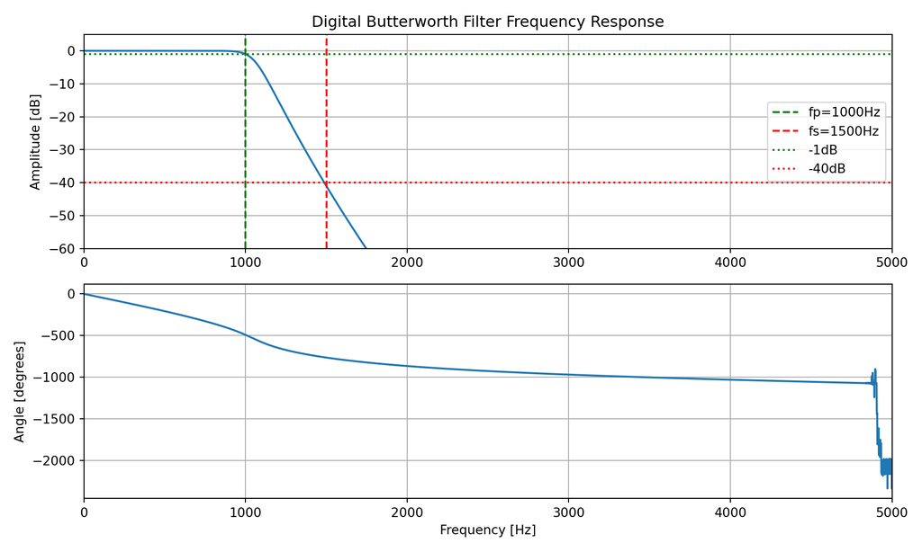

## Step 6: Realization & Filtering (Python Example)

- The coefficients `b`, `a` define the difference equation.
- Use `scipy.signal.lfilter` to apply the filter to a signal.

```
(-1.5, 1.5)
```

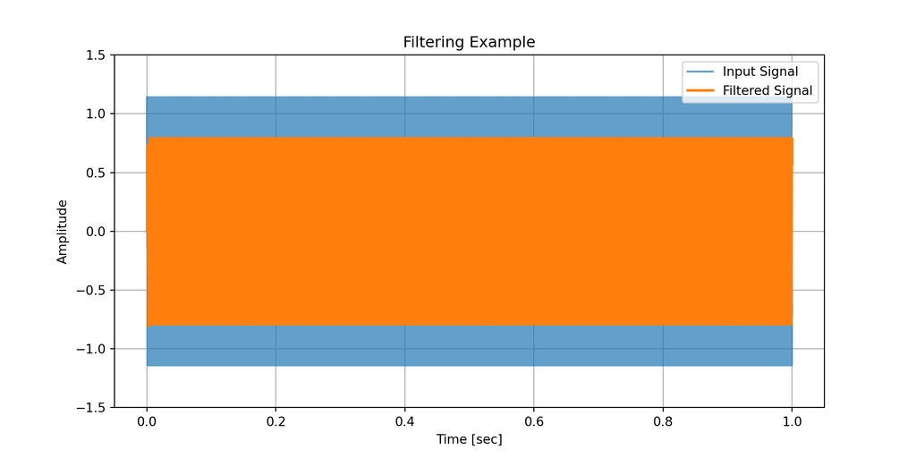

## Summary: IIR Design Process (with Scipy)

1. **Define** Digital Specs ($f_p, f_s, gpass, gstop, F_s$). Normalize frequencies ($W_p, W_s$).
2. **Select** Filter Type (e.g., Butterworth) & find order/cutoff using `buttord` (digital).
3. **Design** Filter to get coefficients ($b, a$) using `butter` (digital).
4. **Analyze** Frequency Response using `freqz`.
5. **Implement/Apply** Filter using `lfilter` (uses the difference equation implicitly).
- *Scipy handles the underlying analog prototype mapping, pre-warping, and bilinear transformation internally.*